# ST405/ST645 Bayesian Data Analysis

Tutorial Questions (4)

Author

Prof. Niamh Cahill

## **Solutions**

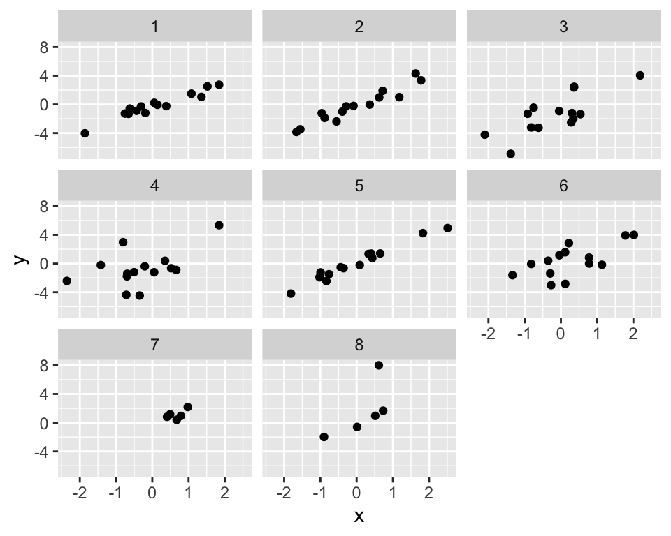

```r
set.seed(28) # set the seed
mean_slope = 2 # the 8 different slopes have a mean of 2
sigma_slope = 0.2 # across group variation
slopes = rnorm(8,mean_slope,sigma_slope) # groups slopes vary around the mean
groups = c(rep(1:6,each = 14),rep(7,5), rep(8,5)) # some groups have smaller sample sizes
sigma <- c(0.5,0.5,2,2,0.5,2,0.5,0.5) # have some groups with large variation
x = rnorm(length(groups)) # simulate a predictor
y =  slopes[groups]*x + rnorm(length(groups),0,sigma[groups]) # simulate y
y[length(groups)] <- 8 # add an outlier
sim_dat <- tibble(x = x, y = y, group = groups) # create the simulated dataset

## Plot the simulated data
ggplot(sim_dat, aes(x = x, y = y)) +
  geom_point() +
  facet_wrap(~group)
```

### Independent slopes regression model

```r
#unpooled regression model
reg_model = "
model{
  for(i in 1:n)
{
 y.i[i] ~ dnorm(mu.i[i],sigma^-2) # data model
 mu.i[i] <- alpha + beta.j[group[i]]*x.i[i]
} # end i loop

for(j in 1:m)
{
 beta.j[j] ~ dnorm(0,10^-2)
}

alpha ~ dnorm(0,2^-2)
sigma ~ dt(0,2^-2,1)T(0,)

}
"

# data
jags.data <- list(y.i = sim_dat$y,
                  x.i = sim_dat$x,
                  group = sim_dat$group,
                  n = nrow(sim_dat),
                  m = sim_dat$group %>% unique() %>% length())
# parameters
parnames <- c("alpha","beta.j","sigma")

# run model
mod <- jags(data = jags.data,
            parameters.to.save = parnames,
            model.file = textConnection(reg_model),
            n.iter = 10000,
            n.burnin = 2000,
            n.thin = 4)
```

```
module glm loaded
```

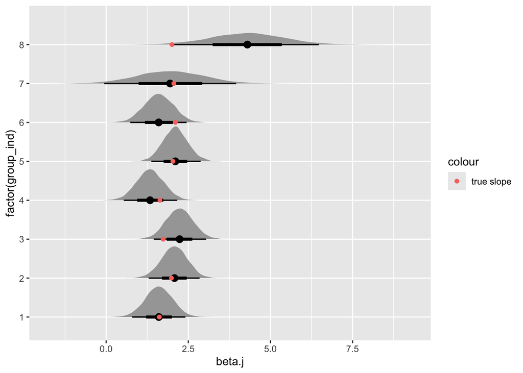

```r
m <- mod$BUGSoutput$sims.matrix

true_slopes <- tibble(slopes, group = factor(1:8))
group_ind <- 1:8

m %>% spread_draws(beta.j[group_ind]) %>%
  ggplot(aes(x = beta.j, y = factor(group_ind))) +
  stat_halfeye() +
  geom_point(data = true_slopes,aes(x = slopes, y = group, colour = "true slope"))
```

```r
mod$BUGSoutput$summary[1:11,]
```

```
                 mean        sd         2.5%         25%         50%
alpha      -0.2252489 0.1672785  -0.55533088  -0.3375414  -0.2222561
beta.j[1]   1.6051527 0.4138870   0.79028381   1.3270774   1.6028980
beta.j[2]   2.0763645 0.3968727   1.29246193   1.8148431   2.0803812
beta.j[3]   2.2358416 0.4079354   1.44693188   1.9589105   2.2364311
beta.j[4]   1.3403526 0.4133098   0.53423682   1.0655847   1.3371259
beta.j[5]   2.1064957 0.3781538   1.37579318   1.8497883   2.1050396
beta.j[6]   1.5983773 0.4443120   0.73481063   1.2998663   1.5992639
beta.j[7]   1.9467638 1.0148389  -0.05837928   1.2517718   1.9460094
beta.j[8]   4.2851103 1.1180318   2.06885210   3.5383206   4.2984878
deviance  349.6253876 4.6423698 342.59040934 346.1974742 348.9947607
sigma       1.5620664 0.1208778   1.34557749   1.4770845   1.5548710
                  75%       97.5%     Rhat n.eff
alpha      -0.1137689   0.1032378 1.001539  2500
beta.j[1]   1.8876500   2.4120777 1.001327  3500
beta.j[2]   2.3425122   2.8422586 1.000903  6000
beta.j[3]   2.5066504   3.0452266 1.000981  6000
beta.j[4]   1.6200396   2.1632080 1.000944  6000
beta.j[5]   2.3522741   2.8746504 1.000780  6000
beta.j[6]   1.8984623   2.4478533 1.003892  5500
beta.j[7]   2.6371574   3.9568606 1.000852  6000
beta.j[8]   5.0309543   6.4726217 1.000769  6000
deviance  352.3155531 360.7800791 1.000760  6000
sigma       1.6412764   1.8145571 1.001491  4300
```

```r
mod$BUGSoutput$DIC
```

```
[1] 360.4047
```

- The true slopes are not as close to the model point estimates for groups 3,4 and 6. The additional variation in these groups is making it a little bit more difficult to estimate the slope. However, the truth is still captured within the uncertainty interval.
- Note the additional paramter uncertainty in groups 7 and 8 relative to the other groups. This is because we have alot less data in these groups.
- Note for group 8 the presence of the outlier is really throwing off the model estimate for the true slope in this group.

## Hierarchical regression model (partial pooling)

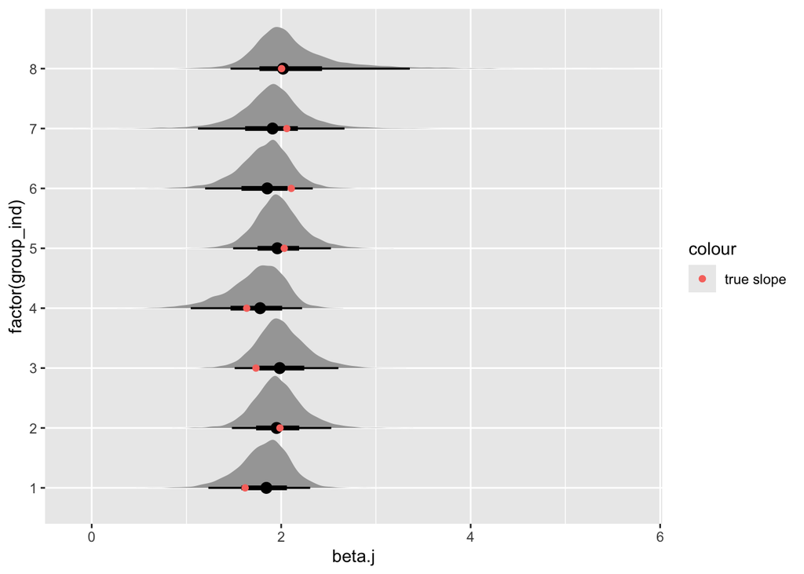

```r
# hierarchical regression model
bhreg_model = "
model{
  for(i in 1:n)
{
 y.i[i] ~ dnorm(mu.i[i],sigma^-2) # data model
 mu.i[i] <- alpha + beta.j[group[i]]*x.i[i]
} # end i loop

for(j in 1:m)
{
  beta.j[j] ~ dnorm(beta_mu,sigma_beta^-2)
}

beta_mu ~ dnorm(0,2^-2)
alpha ~ dnorm(0,2^-2)
sigma ~ dt(0,2^-2,1)T(0,)
sigma_beta ~ dt(0,1^-2,1)T(0,)

}
"

# data
jags.data <- list(y.i = sim_dat$y,
                  x.i = sim_dat$x,
                  group = sim_dat$group,
                  n = nrow(sim_dat),
                  m = sim_dat$group %>% unique() %>% length())
# parameters
parnames <- c("alpha","beta.j","sigma","beta_mu","sigma_beta")

# run model
mod2 <- jags(data = jags.data,
            parameters.to.save = parnames,
            model.file = textConnection(bhreg_model),
            n.iter = 10000,
            n.burnin = 2000,
            n.thin = 4)
m2 <- mod2$BUGSoutput$sims.matrix

true_slopes <- tibble(slopes, group = factor(1:8))
group_ind <- 1:8

m2 %>% spread_draws(beta.j[group_ind]) %>%
  ggplot(aes(x = beta.j, y = factor(group_ind))) +
  stat_halfeye() +
  geom_point(data = true_slopes,aes(x = slopes, y = group, colour = "true slope"))
```

```r
mod2$BUGSoutput$summary[1:13,]
```

```
                  mean        sd          2.5%         25%         50%
alpha       -0.1973181 0.1609220  -0.507684700  -0.3065535  -0.1958043
beta.j[1]    1.8211640 0.2670416   1.231825683   1.6647259   1.8433929
beta.j[2]    1.9653844 0.2610867   1.479816545   1.8016453   1.9511794
beta.j[3]    2.0049589 0.2693437   1.509355808   1.8317054   1.9839997
beta.j[4]    1.7371152 0.3000888   1.045620976   1.5636014   1.7776199
beta.j[5]    1.9717886 0.2502841   1.493099720   1.8130825   1.9595920
beta.j[6]    1.8256476 0.2797139   1.197063847   1.6667844   1.8531568
beta.j[7]    1.9035179 0.3658345   1.121892136   1.7189072   1.9088335
beta.j[8]    2.1135545 0.4590946   1.465829251   1.8411034   2.0199622
beta_mu      1.9108907 0.2112882   1.490594491   1.7827927   1.9149273
deviance   350.6244317 3.2517532 344.811083000 348.6130573 350.2890505
sigma        1.5685836 0.1161054   1.360455747   1.4887792   1.5618756
sigma_beta   0.2870317 0.2416921   0.007592653   0.1090703   0.2322337
                    75%       97.5%     Rhat n.eff
alpha       -0.09084579   0.1244109 1.000919  6000
beta.j[1]    2.00087497   2.3057981 1.001998  1600
beta.j[2]    2.11304134   2.5284858 1.000946  6000
beta.j[3]    2.16335519   2.6036221 1.000993  6000
beta.j[4]    1.94535907   2.2204166 1.003634   700
beta.j[5]    2.11701076   2.5252783 1.001944  1700
beta.j[6]    2.00721554   2.3331026 1.002854  1300
beta.j[7]    2.08777158   2.6679440 1.000834  6000
beta.j[8]    2.27646330   3.3575452 1.002661  2100
beta_mu      2.03792527   2.3367359 1.001913  1700
deviance   352.37954611 358.1345882 1.000943  6000
sigma        1.64258756   1.8108979 1.000973  6000
sigma_beta   0.40147433   0.8997124 1.008081   400
```

```r
mod2$BUGSoutput$DIC
```

```
[1] 355.9121
```

### Some changes to explore in the simulation

- Change the accross slope variation in the simulation to be larger/smaller - you should see the BHM having less/more impact. The bigger the across slope variation the closer you’ll get to the independent model results. Conversely, if the across slope variation is smaller there’ll be more pooling.